# An Introduction to Censored Covariates: Simulation

Marissa Ashner

2/28/2023

### Data Generation

The first part of a simulation is generating the data. We want to generate data that follows this model:

$$y = \beta_1 + \beta_2X + \beta_3Z + \epsilon$$
where $C$ is a censoring value for $X$, $\Delta = I(X\leq C)$, and $W = \min(X,C)$.

```r
# GENERATE SOME DATA

# n is the sample size
n = 2000

# r is the censoring rate (the proportion of observations you want censored)
r = 0.7

# Generate X from a Uniform(0,10)
X = runif(n, 0, 10)

# In order to hit the desired censoring rate, generate C from a Uniform(0, 20(1-r))
## PRACTICE: How was this formula determined?
C = runif(n, 0, 20*(1-r))

# calculate the observed variables
W = pmin(X, C)
D = ifelse(X <= C, 1, 0)

# Generate the other covariate Z from a standard normal
Z = rnorm(n)

# Errors will be generated from a standard normal
eps = rnorm(n)

# Let all parameters be 1
beta = c(1, 1, 1)

# generate the outcome y
y = beta[1] + beta[2]*X + beta[3]*Z + eps

# put all variables into a data frame
data_sim = data.frame(W = W, D = D, Z = Z, y = y, X = X, C = C)
```

### The Oracle Estimator

In a real data set, we will be handed the variables, $W, \Delta, Z, y$ and we won’t know $X$ or $C$ fully. However, in a simulation, since we generated the data, we do know the values of $X$ and $C$. Therefore, we can determine what would happen if $X$ was not censored. We will call this the oracle estimator.

```r
# If we knew the truth... the Oracle Estimator

output_oracle = lm(y~X+Z, data = data_sim)
summary(output_oracle)
```

```
##
## Call:
## lm(formula = y ~ X + Z, data = data_sim)
##
## Residuals:
##     Min      1Q  Median      3Q     Max
## -3.1499 -0.6529 -0.0039  0.6857  3.2138
##
## Coefficients:
##             Estimate Std. Error t value Pr(>|t|)
## (Intercept) 0.994281   0.044433   22.38   <2e-16 ***
## X           1.000527   0.007716  129.67   <2e-16 ***
## Z           0.998426   0.023014   43.38   <2e-16 ***
## ---
## Signif. codes:  0 '***' 0.001 '**' 0.01 '*' 0.05 '.' 0.1 ' ' 1
##
## Residual standard error: 1.002 on 1997 degrees of freedom
## Multiple R-squared:  0.9019, Adjusted R-squared:  0.9018
## F-statistic:  9176 on 2 and 1997 DF,  p-value: < 2.2e-16
```

### The Naive Estimator

What if we just replace $X$ with the observed $W$? This we can do in practice, since we observe $W$, but should we?

```r
# Naive Analysis

output_naive = lm(y~W+Z, data = data_sim)
summary(output_naive)
```

```
##
## Call:
## lm(formula = y ~ W + Z, data = data_sim)
##
## Residuals:
##    Min     1Q Median     3Q    Max
## -5.835 -2.234 -0.455  2.104  7.916
##
## Coefficients:
##             Estimate Std. Error t value Pr(>|t|)
## (Intercept)  3.99050    0.10935   36.49   <2e-16 ***
## W            0.83022    0.03786   21.93   <2e-16 ***
## Z            0.93302    0.06339   14.72   <2e-16 ***
## ---
## Signif. codes:  0 '***' 0.001 '**' 0.01 '*' 0.05 '.' 0.1 ' ' 1
##
## Residual standard error: 2.762 on 1997 degrees of freedom
## Multiple R-squared:  0.255,  Adjusted R-squared:  0.2542
## F-statistic: 341.7 on 2 and 1997 DF,  p-value: < 2.2e-16
```

### The Complete Case Estimator

What if we delete all observations where $\Delta = 0$? This we can also do in practice, since we observe $X$ for all $\Delta = 1$. But should we?

Note in the data generation that we generated $C$ to be completely independent of all other variables, meaning that given the covariates ($X, Z$ here), the probability of being a complete case does not depend on the outcome ($y$ in this case). Based on our notes, this should lead to a consistent estimator.

```r
# Complete Case Analysis using X as a censored covariate

data_sim_cc = data_sim %>% filter(D == 1)
output_cc = lm(y~W+Z, data = data_sim_cc)
summary(output_cc)
```

```
##
## Call:
## lm(formula = y ~ W + Z, data = data_sim_cc)
##
## Residuals:
##      Min       1Q   Median       3Q      Max
## -3.05011 -0.64568  0.03592  0.69207  3.11856
##
## Coefficients:
##             Estimate Std. Error t value Pr(>|t|)
## (Intercept)  0.99477    0.07085   14.04   <2e-16 ***
## W            0.98908    0.03018   32.77   <2e-16 ***
## Z            0.98012    0.04307   22.76   <2e-16 ***
## ---
## Signif. codes:  0 '***' 0.001 '**' 0.01 '*' 0.05 '.' 0.1 ' ' 1
##
## Residual standard error: 1.021 on 607 degrees of freedom
## Multiple R-squared:  0.7211, Adjusted R-squared:  0.7202
## F-statistic: 784.7 on 2 and 607 DF,  p-value: < 2.2e-16
```

### What if the outcome is censored instead?

What if instead, we want to estimate these parameters?:

$$X = \alpha_1 + \alpha_2y + \alpha_3Z + \epsilon_{\alpha}$$
#### The Oracle Estimator

Let’s use the oracle estimator to see what the value of $\alpha_2$ should be.

```r
# If we knew the truth... the Oracle Estimator

output_oracle_alpha = lm(X~y+Z, data = data_sim)
summary(output_oracle_alpha)
```

```
##
## Call:
## lm(formula = X ~ y + Z, data = data_sim)
##
## Residuals:
##     Min      1Q  Median      3Q     Max
## -3.2954 -0.6524  0.0101  0.6431  3.2270
##
## Coefficients:
##             Estimate Std. Error t value Pr(>|t|)
## (Intercept) -0.36042    0.04626  -7.792 1.06e-14 ***
## y            0.89337    0.00689 129.670  < 2e-16 ***
## Z           -0.90216    0.02261 -39.906  < 2e-16 ***
## ---
## Signif. codes:  0 '***' 0.001 '**' 0.01 '*' 0.05 '.' 0.1 ' ' 1
##
## Residual standard error: 0.9472 on 1997 degrees of freedom
## Multiple R-squared:  0.894,  Adjusted R-squared:  0.8938
## F-statistic:  8417 on 2 and 1997 DF,  p-value: < 2.2e-16
```

#### The Complete Case Estimator

Now let’s try the complete case analysis. As discussed in the notes, the probability of being censored is inherently dependent on the value of $X$, which is the outcome. Therefore, we shouldn’t be guaranteed consistency of this estimator.

```r
# Complete Case Analysis using X as a censored outcome

output_cc_alpha = lm(W~y+Z, data = data_sim_cc)
summary(output_cc_alpha)
```

```
##
## Call:
## lm(formula = W ~ y + Z, data = data_sim_cc)
##
## Residuals:
##      Min       1Q   Median       3Q      Max
## -2.36953 -0.60121 -0.04055  0.53084  2.62440
##
## Coefficients:
##             Estimate Std. Error t value Pr(>|t|)
## (Intercept)  0.04550    0.06588   0.691     0.49
## y            0.64594    0.01971  32.771   <2e-16 ***
## Z           -0.64096    0.03960 -16.186   <2e-16 ***
## ---
## Signif. codes:  0 '***' 0.001 '**' 0.01 '*' 0.05 '.' 0.1 ' ' 1
##
## Residual standard error: 0.8255 on 607 degrees of freedom
## Multiple R-squared:  0.639,  Adjusted R-squared:  0.6378
## F-statistic: 537.2 on 2 and 607 DF,  p-value: < 2.2e-16
```

### Running a full simulation study

We just ran one simulation. The data we generated was random, and if we ran it again, we’d get a different set of data and different answers. To conduct a full simulation study, you should go through this process many times (100-1000), and save the parameter estimates. Then you can look at the distribution of parameter estimates and see if the mean is close to what you expect.

This can be done by putting our previous code into some sort of function and/or for loop and saving the estimates at each iteration. You will want to set a seed before you start, so your work is reproducible.

#### Example simulation study for the complete case estimator for a censored covariate

##### Defining the function

```r
simulation_cc <- function(seed){
# GENERATE SOME DATA

set.seed(seed)

# n is the sample size
n = 2000

# r is the censoring rate (the proportion of observations you want censored)
r = 0.7

# Generate X from a Uniform(0,10)
X = runif(n, 0, 10)

# In order to hit the desired censoring rate, generate C from a Uniform(0, 20(1-r))
## PRACTICE: How was this formula determined?
C = runif(n, 0, 20*(1-r))

# calculate the observed variables
W = pmin(X, C)
D = ifelse(X <= C, 1, 0)

# Generate the other covariate Z from a standard normal
Z = rnorm(n)

# Errors will be generated from a standard normal
eps = rnorm(n)

# Let all parameters be 1
beta = c(1, 1, 1)

# generate the outcome y
y = beta[1] + beta[2]*X + beta[3]*Z + eps

# put all variables into a data frame
data_sim = data.frame(W = W, D = D, Z = Z, y = y, X = X, C = C)

data_sim_cc = data_sim %>% filter(D == 1)
output_cc = lm(y~W+Z, data = data_sim_cc)
estimates = summary(output_cc)$coeff[,1]

return(estimates)
}
```

##### Running the function

```r
# run the simulation 100 times for seeds 1 - 100
estimates_100 = lapply(1:100, simulation_cc)

# convert the output into a data frame
estimates_df = as.data.frame(do.call(rbind, estimates_100))

# what is the mean estimate for each parameter?
colMeans(estimates_df)
```

```
## (Intercept)           W           Z
##   1.0082436   0.9999634   1.0016395
```

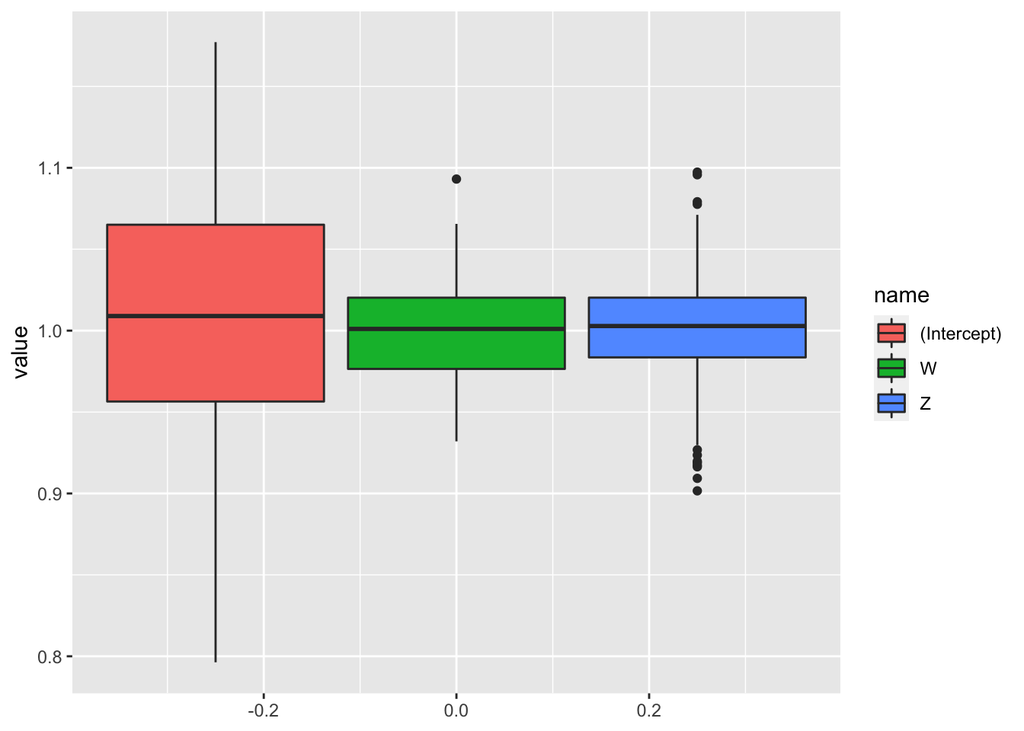

```r
# Now let's plot the results

## First convert the data frame into a long format
estimates_long <- pivot_longer(estimates_df, cols = c(`(Intercept)`, W, Z))

# Now use ggplot to visualize the results
ggplot(estimates_long) + geom_boxplot(aes(y=value, fill=name))
```